# POLS 15 – Section 5 Example Solution

Hunter C. Smith

2026-01-12

We won’t be going over any new code this week. Instead, this is a chance for you to practice the analytical tools we’ve learned so far in the course to prepare for next week’s midterm exam.

### Choose a Dataset

- `wb.RData`: Data from the World Bank for economic and environmental variables from 2005.
- `voters.RData`: Data from a 2016 USC / LA Times Presidential Poll of voter demographics and attitudes toward presidential candidates.
- `nba.RData`: Statistics for NBA teams from 2012-2016.

### Setup

Clear your environment, set your working directory, and upload your dataset of choice.

```r
rm(list = ls())
#setwd("/home/jovyan/UCSB_PS15/Section 5/")
load("voters.RData")
```

### Explore Your Dataset

Identify your sample size, number of variables, and variable names.

```r
nrow(usc4)
```

```
## [1] 1039
```

```r
ncol(usc4)
```

```
## [1] 10
```

```r
names(usc4)
```

```
##  [1] "hhincome"    "education"   "age"         "trump_vote"  "clint_vote"
##  [6] "prob_vote"   "race"        "gender"      "statereside" "vote"
```

Before moving on, hypothesize a relationship between two variables in your dataset. Which is your IV, and which is your DV?

**IV: Education (`education`)**  
**DV: Probability of voting for Hillary Clinton (`clint_vote`)**  
**Hypothesis: education is positively correlated with probability of voting for Clinton**

### Univariate Analysis

For each variable, compute the mean, median, range, and standard deviation. What do these values tell you about the distribution of each variable?

```r
summary(usc4$education)
```

```
##    Min. 1st Qu.  Median    Mean 3rd Qu.    Max.
##    3.00   10.00   11.00   11.22   13.00   16.00
```

```r
sd(usc4$education)
```

```
## [1] 2.168303
```

```r
summary(usc4$clint_vote)
```

```
##    Min. 1st Qu.  Median    Mean 3rd Qu.    Max.
##     0.0     0.0    40.0    44.7   100.0   100.0
```

```r
sd(usc4$clint_vote)
```

```
## [1] 45.25191
```

**Education: Mean $\approx$ median, so probably normally distributed. Small SD, so probably tight distribution.**  
**Clinton Vote: Mean > median, so positively skewed. Large SD, so lots of variation in values (probably lots of extreme values).**

Now, create a distribution plot for each variable (with appropriate labels). Describe each of the distributions.

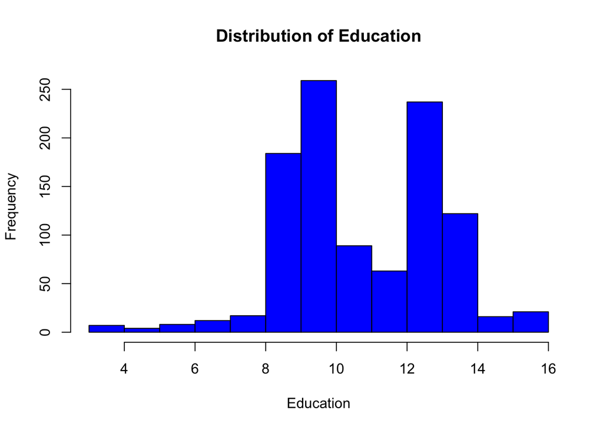

```r
hist(usc4$education,
     xlab = "Education",
     main = "Distribution of Education",
     col = "blue")
```

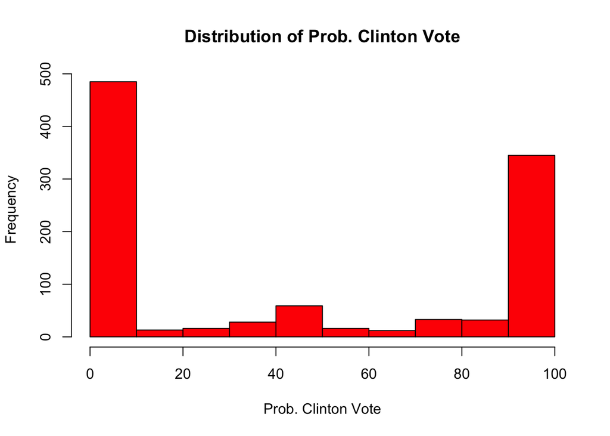

```r
hist(usc4$clint_vote,
     xlab = "Prob. Clinton Vote",
     main = "Distribution of Prob. Clinton Vote",
     col = "red")
```

**Both distributions are bimodal. Modal responses for `clint_vote` are at extreme values while modal responses for `education` are near the center of the distribution.**

### Bivariate Analysis

Compute the covariance and correlation between your variables and interpret each – what do they tell you about the relationship?

```r
cov(usc4$education, usc4$clint_vote)
```

```
## [1] 16.54657
```

```r
cor(usc4$education, usc4$clint_vote)
```

```
## [1] 0.1686363
```

**Covariance: There is a positive association between `education` and `clint_vote`.**  
**Correlation: There is a weak positive correlation between `education` and `clint_vote`.**

Now make a scatterplot of these variables. Is there a clear pattern in the data?

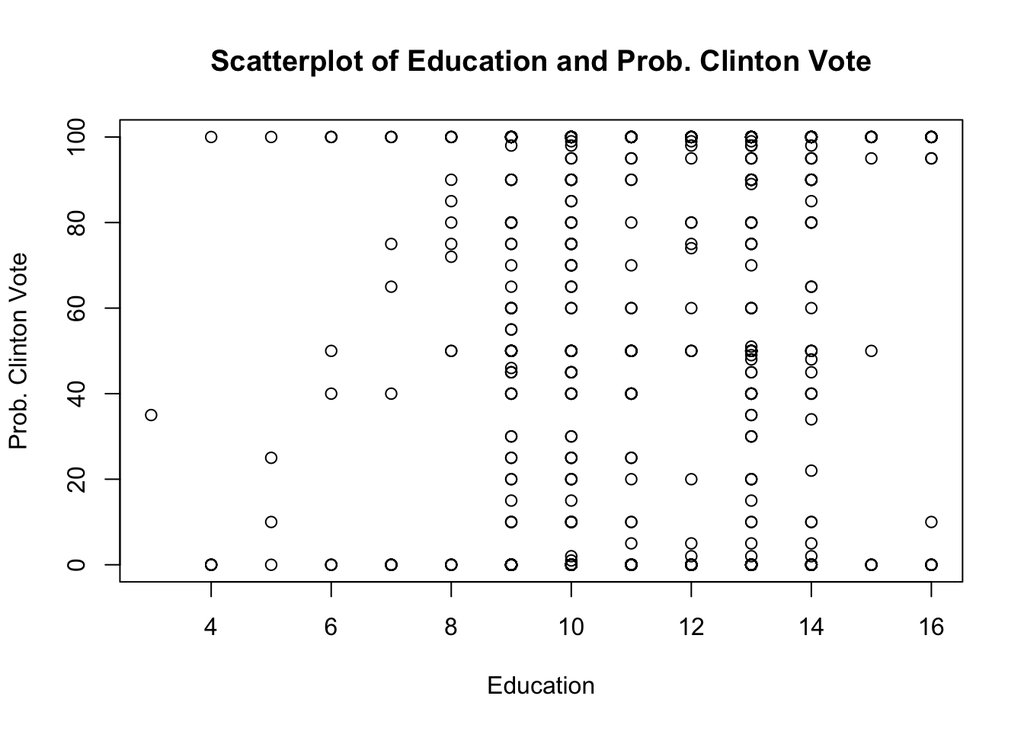

```r
plot(usc4$education, usc4$clint_vote,
     xlab = "Education",
     ylab = "Prob. Clinton Vote",
     main = "Scatterplot of Education and Prob. Clinton Vote")
```

**Difficult to tell visually, but correlation tells us that there should be a slight upward trend.**

Write the regression model you’ll estimate with these variables using appropriate mathematical notation.

Equation:
$$clint\_vote_i = \beta_0 +
\beta_1 education_i + \epsilon_i$$

Now estimate your regression and add the line to your scatterplot. What does the line suggest about the relationship?

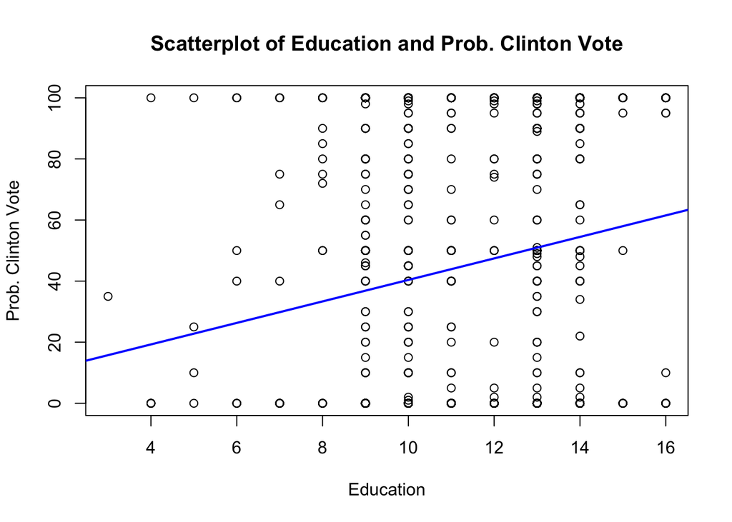

```r
mod1 <- lm(clint_vote ~ education, data = usc4)

plot(usc4$education, usc4$clint_vote,
     xlab = "Education",
     ylab = "Prob. Clinton Vote",
     main = "Scatterplot of Education and Prob. Clinton Vote")
abline(mod1, col = "blue", lwd = 2)
```

**Confirms that there is a positive relationship because the regression line has a positive slope.**

Finally, pull up the model summary and do the following:

- Interpret $\hat{\beta_0}$.
- Interpret $\hat{\beta_1}$.
- Specify your null hypothesis using both mathematical notation and words.
- Specify your alternate hypothesis using both mathematical notation and words.
- Interpret the $p$-value for $\hat{\beta_1}$ and state your conclusions regarding significance and your hypotheses.
- Interpret $R^2$.

```r
summary(mod1)
```

```
##
## Call:
## lm(formula = clint_vote ~ education, data = usc4)
##
## Residuals:
##    Min     1Q Median     3Q    Max
## -61.51 -40.39 -10.95  48.55  80.72
##
## Coefficients:
##             Estimate Std. Error t value Pr(>|t|)
## (Intercept)   5.1976     7.3019   0.712    0.477
## education     3.5194     0.6388   5.509 4.54e-08 ***
## ---
## Signif. codes:  0 '***' 0.001 '**' 0.01 '*' 0.05 '.' 0.1 ' ' 1
##
## Residual standard error: 44.63 on 1037 degrees of freedom
## Multiple R-squared:  0.02844,    Adjusted R-squared:  0.0275
## F-statistic: 30.35 on 1 and 1037 DF,  p-value: 4.541e-08
```

**$\hat{\beta_0}$: When a person has not received any education, their predicted probability of voting for Clinton is 5.19 percentage points.**  
**$\hat{\beta_1}$: A one-year increase in education is associated with a 3.52 percentage point increase in the probability of voting for Clinton.**

**$H_0: \beta_1 = 0$. Education does *not* affect the probability of voting for Clinton.**  
**$H_A: \beta_1 \neq 0$. Education *does* affect the probability of voting for Clinton.**

**The $p$-value associated with $\hat{\beta_1}$ is 0.0000000454. This is less than the standard significance threshold ($\alpha = 0.05$), so we have sufficient evidence to reject the hull hypothesis.**

**$R^2$ = 0.02844, indicating that the specified model explains 2.84 percent of the variation we observe in the probability of voting for Clinton. Because this is a bivariate model, we can also say that accounting for education explains about 2.84 of the variation we observe in the probability of voting for Clinton.**

### Bonus – Heterogeneous Effects

If you have time, choose another variable from your dataset that might influence your results (think back to the example from Week 3 with the terror data). Create a meaningful subset of your data and compare the means of your variables. Does it seem like there may be heterogeneous effects?

```r
mean(usc4$education[usc4$age >= mean(usc4$age)])
```

```
## [1] 11.21042
```

```r
mean(usc4$education[usc4$age < mean(usc4$age)])
```

```
## [1] 11.23608
```

```r
mean(usc4$clint_vote[usc4$age >= mean(usc4$age)])
```

```
## [1] 46.63127
```

```r
mean(usc4$clint_vote[usc4$age < mean(usc4$age)])
```

```
## [1] 42.77351
```

```r
usc4$age_bin <- ifelse(usc4$age >= mean(usc4$age), 1, 0) # creating a binary variable based on the age breakpoint used above
t.test(usc4$clint_vote ~ usc4$age_bin) # testing whether the difference in clint_vote based on age_bin is significant
```

```
##
##  Welch Two Sample t-test
##
## data:  usc4$clint_vote by usc4$age_bin
## t = -1.3744, df = 1035.5, p-value = 0.1696
## alternative hypothesis: true difference in means between group 0 and group 1 is not equal to 0
## 95 percent confidence interval:
##  -9.365486  1.649963
## sample estimates:
## mean in group 0 mean in group 1
##        42.77351        46.63127
```

**Very slight difference-in-means for `education` based on age, but larger for `clint_vote`. The $p$-value reported in the t-test demonstrates that this difference is not statistically significant, though, so there are likely not heterogeneous effects based on age.**